# Latihan Basic Data Visualisasi Eksplorasi_DSC

Prasdianitaningtiyas Junita Kusuma

October 18, 2019

# IMPORT DATA SET

```r
data("mtcars")
df <- data.frame(mtcars)
```

Data set yang digunakan untuk latihan kali ini adalah data set mtcars, dimana data tersebut diambil dari database software R. Data set mtcars berisi tentang spesifikasi dari beberapa varian mobil. Data diambil dari majalah Motor Trend US 1974, dan terdiri dari konsumsi bahan bakar dan 10 aspek desain dan kinerja mobil untuk 32 mobil (model 1973-1974).

# CEK DATA SET

## Menampilkan struktur data atau jenis data untuk masing-masing kolom.

```r
str(df)
```

```
## 'data.frame':    32 obs. of  11 variables:
##  $ mpg : num  21 21 22.8 21.4 18.7 18.1 14.3 24.4 22.8 19.2 ...
##  $ cyl : num  6 6 4 6 8 6 8 4 4 6 ...
##  $ disp: num  160 160 108 258 360 ...
##  $ hp  : num  110 110 93 110 175 105 245 62 95 123 ...
##  $ drat: num  3.9 3.9 3.85 3.08 3.15 2.76 3.21 3.69 3.92 3.92 ...
##  $ wt  : num  2.62 2.88 2.32 3.21 3.44 ...
##  $ qsec: num  16.5 17 18.6 19.4 17 ...
##  $ vs  : num  0 0 1 1 0 1 0 1 1 1 ...
##  $ am  : num  1 1 1 0 0 0 0 0 0 0 ...
##  $ gear: num  4 4 4 3 3 3 3 4 4 4 ...
##  $ carb: num  4 4 1 1 2 1 4 2 2 4 ...
```

Data set terdiri dari 32 observasi atau pengamatan dan terdiri dari 11 variabel. Berikut keterangan dari 11 variabel tersebut: mpg : Miles/(US) gallon cyl : Number of cylinders disp: Displacement (cu.in.) hp : Gross horsepower drat: Rear axle ratio wt : Weight (1000 lbs) qsec: 1/4 mile time vs : Engine (0 = V-shaped, 1 = straight) am : Transmission (0 = automatic, 1 = manual) gear: Number of forward gears carb: Number of carburetors

## menampilkan 6 observasi teratas

```r
head(df)
```

```
##                    mpg cyl disp  hp drat    wt  qsec vs am gear carb
## Mazda RX4         21.0   6  160 110 3.90 2.620 16.46  0  1    4    4
## Mazda RX4 Wag     21.0   6  160 110 3.90 2.875 17.02  0  1    4    4
## Datsun 710        22.8   4  108  93 3.85 2.320 18.61  1  1    4    1
## Hornet 4 Drive    21.4   6  258 110 3.08 3.215 19.44  1  0    3    1
## Hornet Sportabout 18.7   8  360 175 3.15 3.440 17.02  0  0    3    2
## Valiant           18.1   6  225 105 2.76 3.460 20.22  1  0    3    1
```

Berdasarkan fungsi (head) tersebut dapat diketahui bahwa observasi pertama pada data set mtcars yaitu varian mobil mazda Rx4 dengan spesifikasi mobil yang dapat dilihat di kolom-kolom berikutnya mulai dari mpg, cyl, sampai carb.

## menampilkan 6 observasi terbawah

```r
tail(df)
```

```
##                 mpg cyl  disp  hp drat    wt qsec vs am gear carb
## Porsche 914-2  26.0   4 120.3  91 4.43 2.140 16.7  0  1    5    2
## Lotus Europa   30.4   4  95.1 113 3.77 1.513 16.9  1  1    5    2
## Ford Pantera L 15.8   8 351.0 264 4.22 3.170 14.5  0  1    5    4
## Ferrari Dino   19.7   6 145.0 175 3.62 2.770 15.5  0  1    5    6
## Maserati Bora  15.0   8 301.0 335 3.54 3.570 14.6  0  1    5    8
## Volvo 142E     21.4   4 121.0 109 4.11 2.780 18.6  1  1    4    2
```

sedangkan 6 observasi terakhir pada data set tersebut yaitu varian mobil Porsche 914-2, Lotus Europa, Ford Pantera L, Ferrari Dino, Maserati Bora, dan Volvo 142E.

## Merubah variabel vs dan am dari tipe numerik menjadi kategorik

```r
df$vs <- as.factor(df$vs)
df$am <- as.factor(df$am)
```

## Ringkasan Data

```r
summary(df)
```

```
##       mpg             cyl             disp             hp
##  Min.   :10.40   Min.   :4.000   Min.   : 71.1   Min.   : 52.0
##  1st Qu.:15.43   1st Qu.:4.000   1st Qu.:120.8   1st Qu.: 96.5
##  Median :19.20   Median :6.000   Median :196.3   Median :123.0
##  Mean   :20.09   Mean   :6.188   Mean   :230.7   Mean   :146.7
##  3rd Qu.:22.80   3rd Qu.:8.000   3rd Qu.:326.0   3rd Qu.:180.0
##  Max.   :33.90   Max.   :8.000   Max.   :472.0   Max.   :335.0
##       drat             wt             qsec       vs     am          gear
##  Min.   :2.760   Min.   :1.513   Min.   :14.50   0:18   0:19   Min.   :3.000
##  1st Qu.:3.080   1st Qu.:2.581   1st Qu.:16.89   1:14   1:13   1st Qu.:3.000
##  Median :3.695   Median :3.325   Median :17.71                 Median :4.000
##  Mean   :3.597   Mean   :3.217   Mean   :17.85                 Mean   :3.688
##  3rd Qu.:3.920   3rd Qu.:3.610   3rd Qu.:18.90                 3rd Qu.:4.000
##  Max.   :4.930   Max.   :5.424   Max.   :22.90                 Max.   :5.000
##       carb
##  Min.   :1.000
##  1st Qu.:2.000
##  Median :2.000
##  Mean   :2.812
##  3rd Qu.:4.000
##  Max.   :8.000
```

Berdasarkan statistik deskriptif dari 9 variabel (tipe numerik) dapat diketahui nilai minimal, mean (rata-rata), maksimal, median, kuartil 1, dan kuartil 3. untuk variabel kategorik yaitu vs dan am, dapat diketahui bahwa untuk variabel vs jumlah varian mobil yang memiliki spesifikasi V-shaped sebanyak 18 dan straight sebanyak 14. sedangkan untuk variabel am jumlah varian mobil yang memiliki spesifikasi automatic sebanyak 19 dan manual sebanyak 13 mobil.

# mendeteksi missing value

```r
#deteksi missing value tiap variabel
is.na(df$mpg)
```

```
##  [1] FALSE FALSE FALSE FALSE FALSE FALSE FALSE FALSE FALSE FALSE FALSE FALSE
## [13] FALSE FALSE FALSE FALSE FALSE FALSE FALSE FALSE FALSE FALSE FALSE FALSE
## [25] FALSE FALSE FALSE FALSE FALSE FALSE FALSE FALSE
```

```r
is.na(df$cyl)
```

```
##  [1] FALSE FALSE FALSE FALSE FALSE FALSE FALSE FALSE FALSE FALSE FALSE FALSE
## [13] FALSE FALSE FALSE FALSE FALSE FALSE FALSE FALSE FALSE FALSE FALSE FALSE
## [25] FALSE FALSE FALSE FALSE FALSE FALSE FALSE FALSE
```

```r
#deteksi missing value secara keseluruhan
summary(is.na(df))
```

```
##     mpg             cyl             disp             hp
##  Mode :logical   Mode :logical   Mode :logical   Mode :logical
##  FALSE:32        FALSE:32        FALSE:32        FALSE:32
##     drat             wt             qsec             vs
##  Mode :logical   Mode :logical   Mode :logical   Mode :logical
##  FALSE:32        FALSE:32        FALSE:32        FALSE:32
##      am             gear            carb
##  Mode :logical   Mode :logical   Mode :logical
##  FALSE:32        FALSE:32        FALSE:32
```

```r
#atau
sapply(df, function(x) sum(is.na(x)))
```

```
##  mpg  cyl disp   hp drat   wt qsec   vs   am gear carb
##    0    0    0    0    0    0    0    0    0    0    0
```

Setelah dilakukan deteksi missing value, dapat disimpulkan bahwa pada data set mtcars tidak terdapat mising value atau data yang kosong.

# Visualisasi data

## Contoh scatter plot

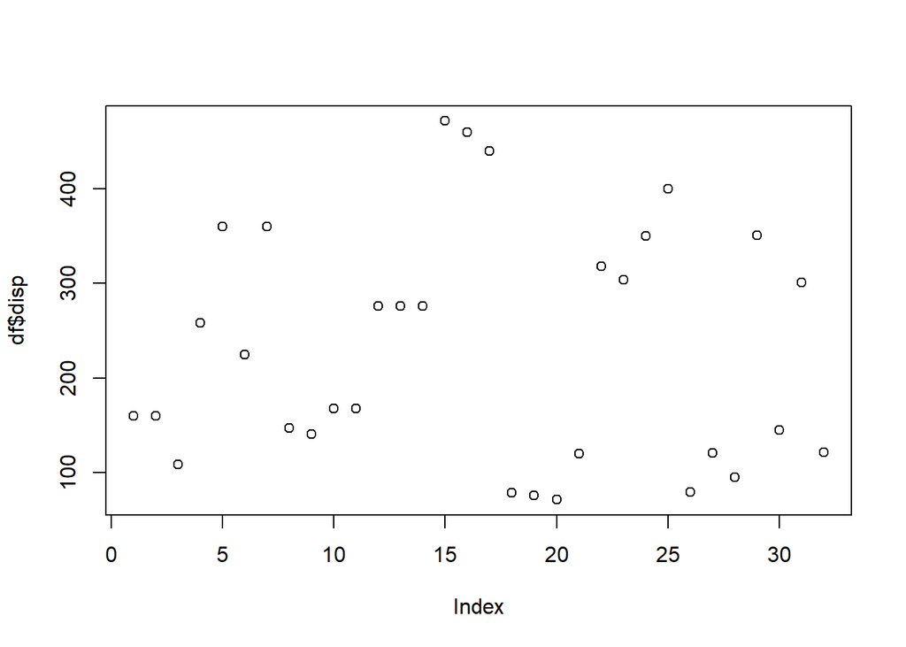

```r
plot(df$disp)
```

Dari scatter plot tersebut nampak bahwa pola data menyebar.

## basic plot both => point and line

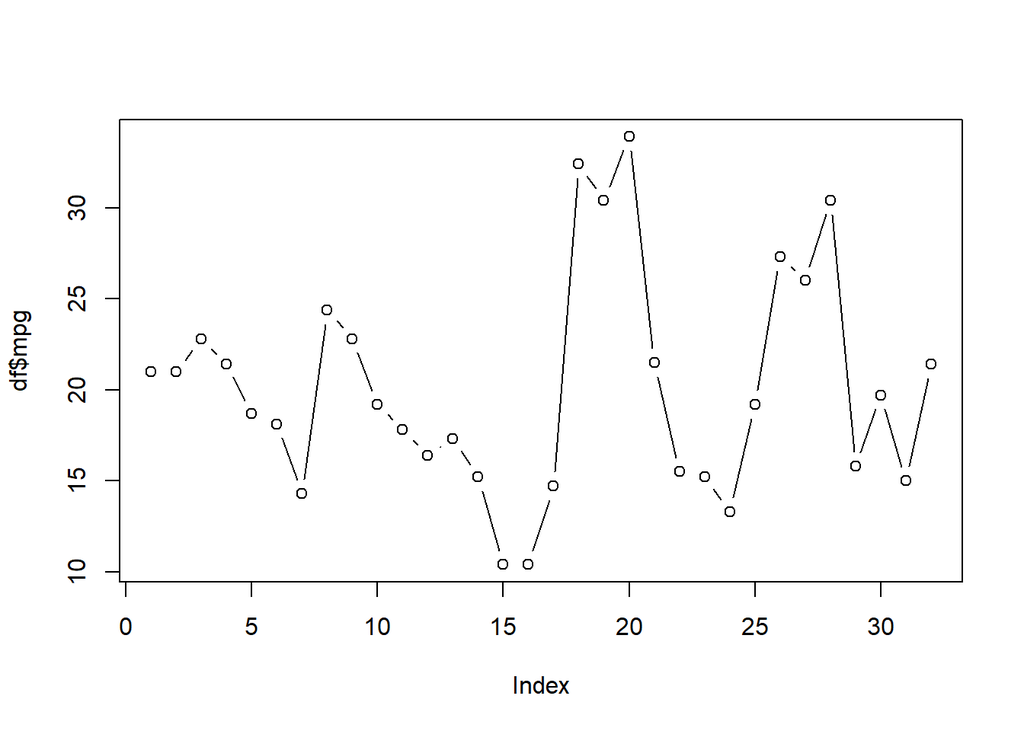

```r
plot(df$mpg, type='b')
```

berdasarkan plot diatas menunjukkan bahwa pada variabel mpg observasi yang memiliki nilai tertinggi yaitu pada observasi ke 20 (varian mobil Toyota Corolla).

## memampilkan garis rata-rata

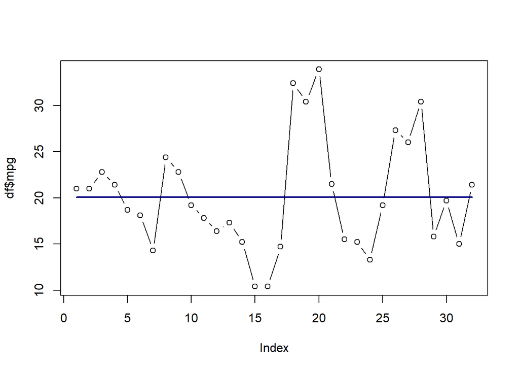

```r
plot(df$mpg, type = 'b')
lines(seq(1:nrow(df)),
      rep(mean(df$mpg),32),lwd = 2,col='navy')
```

# menampilkan plot x=hp dan y= mpg

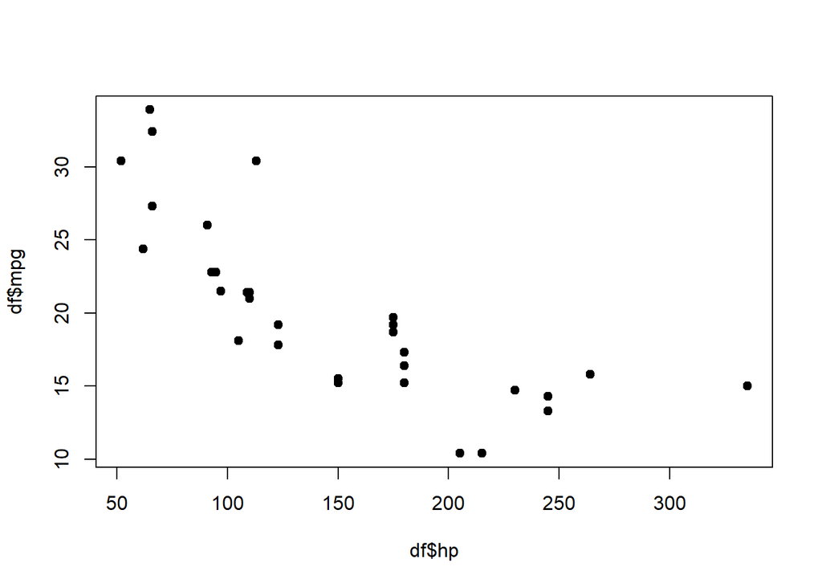

```r
plot(df$hp,df$mpg, pch=19)
```

# menampilkan hubungan antar 2 variabel

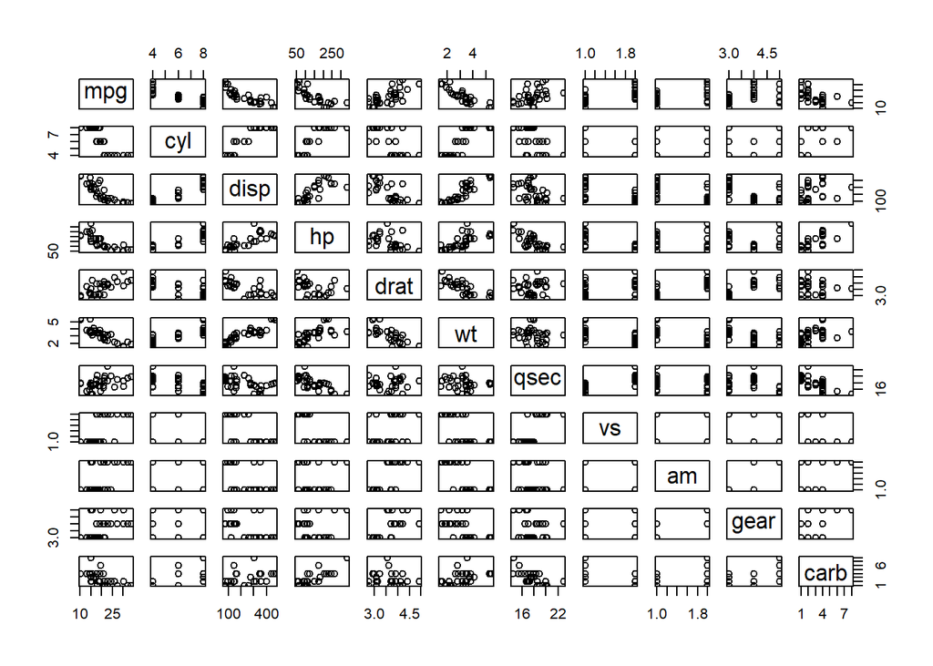

```r
plot(df)
```

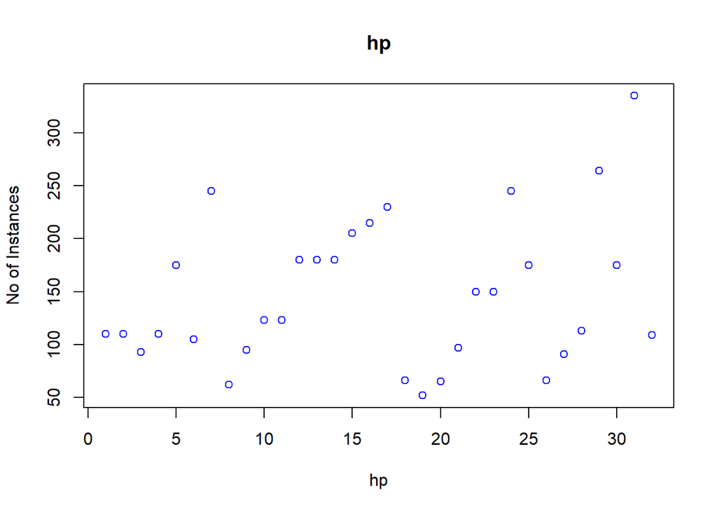

```r
plot(df$hp, xlab = 'hp', ylab = 'No of Instances', main = 'hp', col = 'blue')
```

# bar plot

## horizontal bar plot

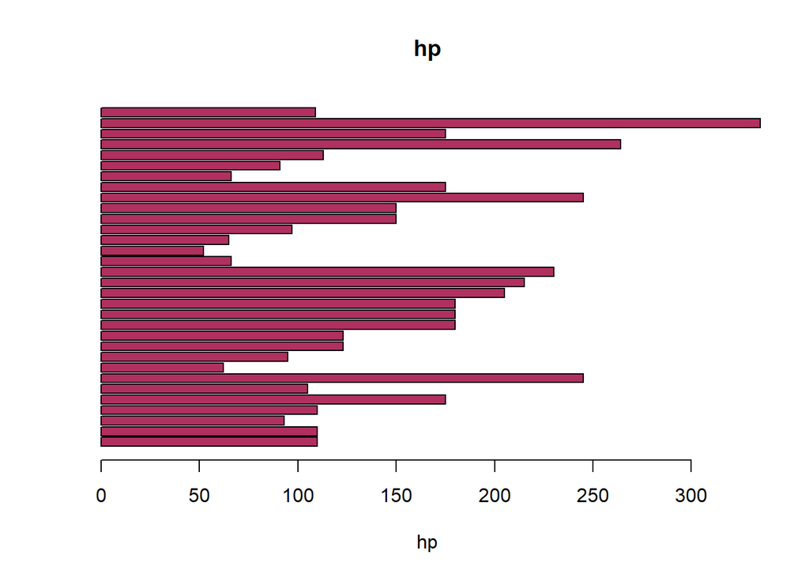

```r
barplot(df$hp, main = 'hp',xlab = 'hp', col= 'maroon',horiz = TRUE)
```

berdasaran grafik tersebut dapat diketahui bahwa varian mobil yang memiliki nilai terbanyak untuk variabel hp yaitu Maserati Bora (observasi ke 31).

## vertikal bar plot

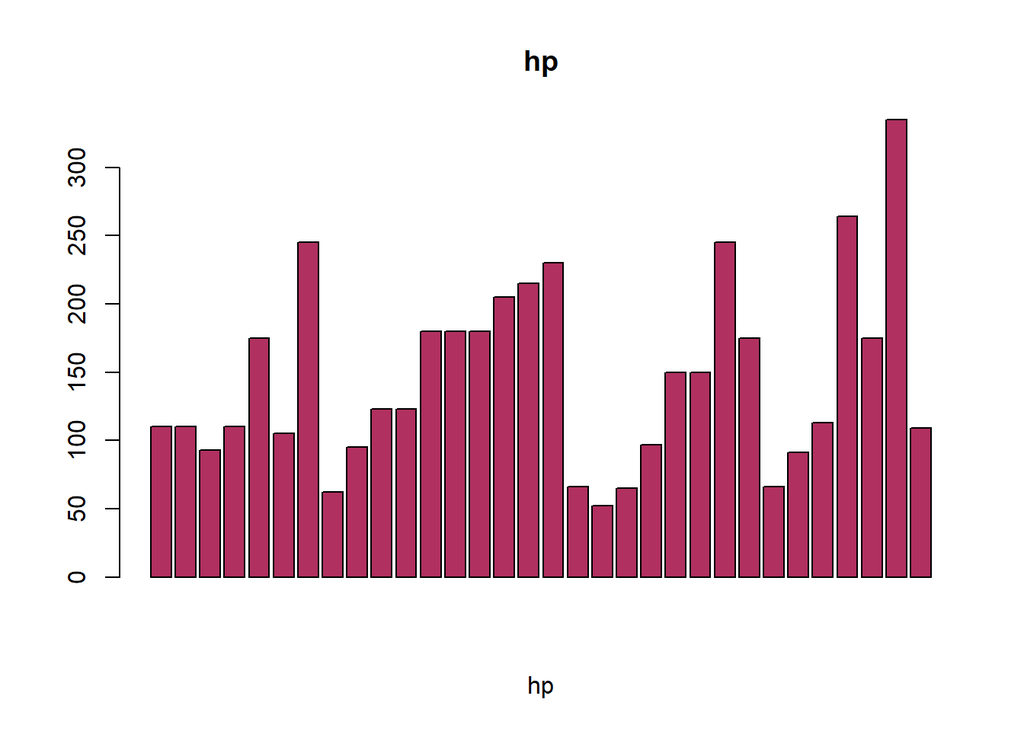

```r
barplot(df$hp, main = 'hp',xlab = 'hp', col= 'maroon',horiz = FALSE)
```